# STAT 300 Homework #7

### Question 1: Suppose we have data that includes information on movies that come out of Hollywood in 2011. We want to build a model to predict profitability, which is the percent of the budget recovered in profits. The dataset contains five explanatory variables and the details are as follows.

### Variable Name: Description

### Rotten Totatoes: Mean rating of critical reviews, from the Rotten Tomatoes website

### AudienceScore: Average audience score, from the Rotten Tomatoes website

### TheatersOpenWeek: Number of theaters showing the movie on opening weekend

### BOAverageOpenWeek: Average box office revenue per theater opening week-end, in dollars

### DomesticGross: Gross revenue in the US by the end of 2011, in millions of dollars

```r
library(corrplot)
library(leaps)
library(car)
```

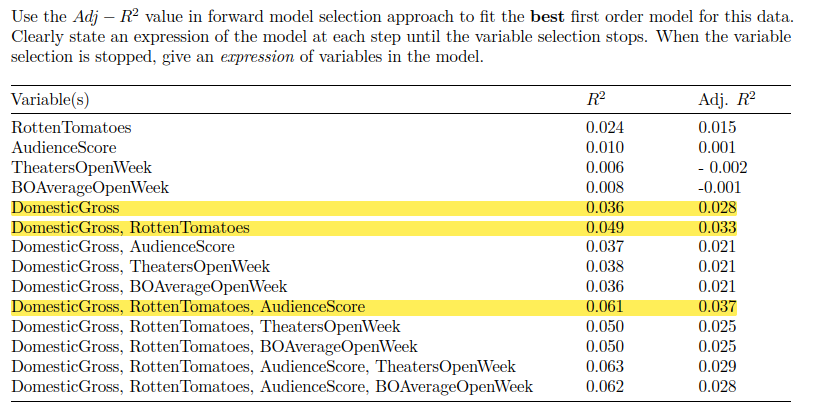

### Profitability ~ DomesticGross

### Profitability ~ DomesticGross + RottenTomatoes

### Profitability ~ DomesticGross + RottenTomatoes + AudienceScore

### Question 2: A research group collected data from a random sample of women who were having trouble getting pregnant. Data is in Fertility.csv file. Variable description is as follows:

### Age - Age in years MeanAFC - Average antral follicle count

### FSH - Maximum follicle stimulating hormone level

### E2 - Fertility level

### MaxE2 - Maximum fertility level

### MaxDailyGn - Maximum daily gonadotropin level

### TotalGn - Total gonadotropin level

### Oocytes - Number of egg cells

### Embryos - Number of embryos

### The research group is interested in developing a model to predict the MeanAFC.

### (a). If you were to use the best subset approach to select a model, how many potential models should you check in the process?

### $\displaystyle\sum_{k = 0}^{p} \binom{p}{k} = 2^p$ where p = number of predictors. In this case, we have 8 predictors so $\displaystyle\sum_{k = 0}^{8} \binom{8}{k} = 2^8$ = 256

### (b). Use the AIC in bi-directional selection to obtain a model

```r
read.csv(file = 'Fertility.csv')
```

| Age | MeanAFC | FSH | E2 | MaxE2 | MaxDailyGn | TotalGn | Oocytes | Embryos |
| --- | --- | --- | --- | --- | --- | --- | --- | --- |
| 40 | 51.5 | 5.3 | 45 | 1427 | 300.0 | 2700.0 | 25 | 13 |
| 37 | 41.0 | 7.1 | 53 | 802 | 225.0 | 1800.0 | 7 | 6 |
| 40 | 41.0 | 4.9 | 40 | 4533 | 450.0 | 4850.0 | 27 | 15 |
| 40 | 37.5 | 3.9 | 26 | 1804 | 300.0 | 2700.0 | 9 | 4 |
| 30 | 36.0 | 4.0 | 49 | 2526 | 150.0 | 1500.0 | 19 | 12 |
| 29 | 35.0 | 3.9 | 67 | 3812 | 150.0 | 975.0 | 19 | 16 |
| 31 | 35.0 | 3.8 | 49 | 1087 | 262.5 | 2512.5 | 13 | 9 |
| 33 | 34.0 | 4.3 | 20 | 1615 | 375.0 | 3075.0 | 15 | 9 |
| 36 | 33.0 | 4.9 | 60 | 1879 | 300.0 | 4800.0 | 23 | 10 |
| 35 | 32.0 | 3.7 | 36 | 2009 | 225.0 | 1275.0 | 26 | 8 |

[output cut: 323 more lines]

```r
fertility <- read.csv(file = 'Fertility.csv')
nullModel <- lm(MeanAFC ~ 1, data = fertility)
fullModel <- lm(MeanAFC ~ Age + FSH + E2 + MaxE2 + MaxDailyGn + TotalGn + Oocytes + Embryos, data = fertility)
step(nullModel, scope = list(lower = nullModel, upper = fullModel), direction = 'both')
```

```
Start:  AIC=1336.46
MeanAFC ~ 1

             Df Sum of Sq   RSS    AIC
+ Oocytes     1    3188.6 15127 1274.8
+ MaxDailyGn  1    2881.9 15434 1281.5
+ TotalGn     1    2699.6 15616 1285.4
+ Embryos     1    2197.8 16118 1295.9
+ FSH         1    1608.8 16707 1307.8
+ MaxE2       1    1105.5 17210 1317.7
+ Age         1     966.3 17349 1320.4
+ E2          1     296.9 18019 1333.0
<none>                    18316 1336.5

Step:  AIC=1274.76
MeanAFC ~ Oocytes

             Df Sum of Sq   RSS    AIC
+ MaxDailyGn  1    1565.3 13562 1240.4
+ TotalGn     1    1472.1 13655 1242.7
+ FSH         1     628.8 14498 1262.6
+ Age         1     618.0 14509 1262.9
+ E2          1     114.3 15013 1274.2
<none>                    15127 1274.8
+ Embryos     1      39.0 15088 1275.9
+ MaxE2       1      31.0 15096 1276.1
- Oocytes     1    3188.6 18316 1336.5

Step:  AIC=1240.39
MeanAFC ~ Oocytes + MaxDailyGn

             Df Sum of Sq   RSS    AIC
+ E2          1    170.17 13392 1238.2
+ FSH         1    105.21 13457 1239.8
<none>                    13562 1240.4
+ TotalGn     1     39.87 13522 1241.4
+ Embryos     1     32.98 13529 1241.6
+ Age         1      9.73 13552 1242.2
+ MaxE2       1      2.76 13559 1242.3
- MaxDailyGn  1   1565.35 15127 1274.8
```

[output cut: 23 more lines]

```
+ TotalGn     1     14.52 13244 1238.5
+ Age         1      7.34 13251 1238.7
+ MaxE2       1      2.75 13256 1238.8
- E2          1    198.17 13457 1239.8
- MaxDailyGn  1   1056.80 14315 1260.4
- Oocytes     1   1452.92 14711 1269.5

Call:
lm(formula = MeanAFC ~ Oocytes + MaxDailyGn + E2 + FSH, data = fertility)

Coefficients:
(Intercept)      Oocytes   MaxDailyGn
   18.80146      0.37893     -0.01747
         E2          FSH
   -0.05142     -0.37200
```

### The model is MeanAFC ~ Oocytes + MaxDailyGn + E2 + FSH

### (c) Fit the model with the predictors you selected in part b. Write down the equation of the fitted regression model

```r
best_model <- lm(MeanAFC ~ Oocytes + MaxDailyGn + E2 + FSH, data = fertility)
summary(best_model)
```

```
Call:
lm(formula = MeanAFC ~ Oocytes + MaxDailyGn + E2 + FSH, data = fertility)

Residuals:
    Min      1Q  Median      3Q     Max
-14.312  -3.413  -0.923   2.595  32.752

Coefficients:
             Estimate Std. Error t value
(Intercept) 18.801458   2.072504   9.072
Oocytes      0.378927   0.063204   5.995
MaxDailyGn  -0.017469   0.003417  -5.113
E2          -0.051418   0.023222  -2.214
FSH         -0.372004   0.204916  -1.815
            Pr(>|t|)
(Intercept)  < 2e-16 ***
Oocytes     5.36e-09 ***
MaxDailyGn  5.40e-07 ***
E2            0.0275 *
FSH           0.0704 .
---
Signif. codes:
  0 ‘***’ 0.001 ‘**’ 0.01 ‘*’ 0.05 ‘.’ 0.1
  ‘ ’ 1

Residual standard error: 6.358 on 328 degrees of freedom
Multiple R-squared:  0.2761,    Adjusted R-squared:  0.2673
F-statistic: 31.28 on 4 and 328 DF,  p-value: < 2.2e-16
```

### The equation of the fitted regression model is 18.801458 + 0.378927(Oocytes) - 0.017469(MaxDailyGn) - 0.051418(E2) - 0.372004(FSH)

### (d). Check the validity of the assumptions for the model you pick in part b

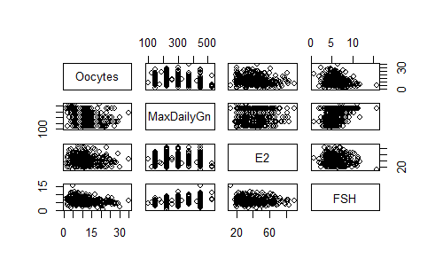

```r
pairs(fertility[, c('Oocytes', 'MaxDailyGn', 'E2', 'FSH')])
```

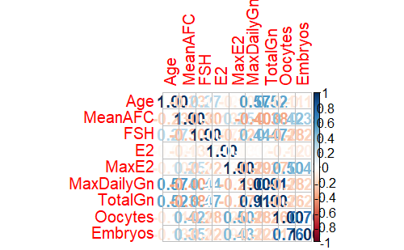

```r
FertCorMat <- cor(fertility, method = 'pearson')
corrplot(FertCorMat, method = 'number')
```

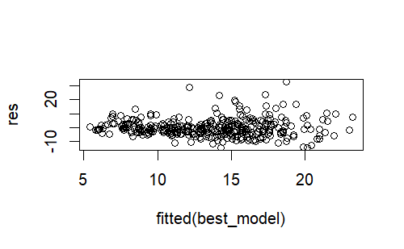

```r
res <- resid(best_model)
plot(fitted(best_model), res)
```

### Independence: It is mentioned that the data collected is from a random sample of women who were having trouble getting pregnant so we can assume independence

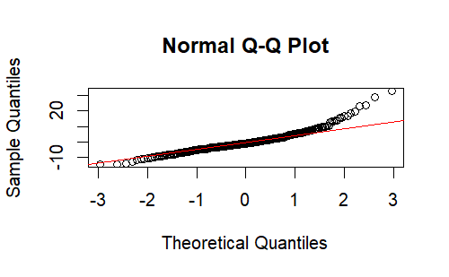

```r
qqnorm(res)
qqline(res, col = 'red')
```

### Normality: Based on the QQ plot, a majority of points follow the reference line but towards the right, points curve upwards, suggesting skewed right residuals

### Equal Variance: The points in the residual plot seem to be randomly scattered around the 0 horizontal line, suggesting constant variance

### (e). What is the coefficient of determination for the model chose in part b?

### $R^2$ = 0.2761

### (f). Now use BIC in bi-directional selection to obtain a model

```r
step(nullModel, scope = list(lower = nullModel, upper = fullModel), direction = 'both', k = log(nrow(fertility)))
```

```
Start:  AIC=1340.26
MeanAFC ~ 1

             Df Sum of Sq   RSS    AIC
+ Oocytes     1    3188.6 15127 1282.4
+ MaxDailyGn  1    2881.9 15434 1289.1
+ TotalGn     1    2699.6 15616 1293.0
+ Embryos     1    2197.8 16118 1303.5
+ FSH         1    1608.8 16707 1315.5
+ MaxE2       1    1105.5 17210 1325.3
+ Age         1     966.3 17349 1328.0
<none>                    18316 1340.3
+ E2          1     296.9 18019 1340.6

Step:  AIC=1282.38
MeanAFC ~ Oocytes

             Df Sum of Sq   RSS    AIC
+ MaxDailyGn  1    1565.3 13562 1251.8
+ TotalGn     1    1472.1 13655 1254.1
+ FSH         1     628.8 14498 1274.0
+ Age         1     618.0 14509 1274.3
<none>                    15127 1282.4
+ E2          1     114.3 15013 1285.7
+ Embryos     1      39.0 15088 1287.3
+ MaxE2       1      31.0 15096 1287.5
- Oocytes     1    3188.6 18316 1340.3

Step:  AIC=1251.81
MeanAFC ~ Oocytes + MaxDailyGn

             Df Sum of Sq   RSS    AIC
<none>                    13562 1251.8
+ E2          1    170.17 13392 1253.4
+ FSH         1    105.21 13457 1255.0
+ TotalGn     1     39.87 13522 1256.6
+ Embryos     1     32.98 13529 1256.8
+ Age         1      9.73 13552 1257.4
+ MaxE2       1      2.76 13559 1257.5
- MaxDailyGn  1   1565.35 15127 1282.4
- Oocytes     1   1872.04 15434 1289.1

Call:
lm(formula = MeanAFC ~ Oocytes + MaxDailyGn, data = fertility)

Coefficients:
(Intercept)      Oocytes   MaxDailyGn
   14.64770      0.41806     -0.01952
```

### The model is MeanAFC ~ Oocytes + MaxDailyGn

### (g). Fit the model with the predictors you selected in part f. Write down the equation of the fitted regression model

```r
bic_best_model <- lm(MeanAFC ~ Oocytes + MaxDailyGn, data = fertility)
summary(bic_best_model)
```

```
Call:
lm(formula = MeanAFC ~ Oocytes + MaxDailyGn, data = fertility)

Residuals:
    Min      1Q  Median      3Q     Max
-13.660  -3.789  -1.043   2.846  32.258

Coefficients:
             Estimate Std. Error t value
(Intercept) 14.647697   1.423960  10.287
Oocytes      0.418061   0.061942   6.749
MaxDailyGn  -0.019523   0.003163  -6.172
            Pr(>|t|)
(Intercept)  < 2e-16 ***
Oocytes     6.69e-11 ***
MaxDailyGn  1.98e-09 ***
---
Signif. codes:
  0 ‘***’ 0.001 ‘**’ 0.01 ‘*’ 0.05 ‘.’ 0.1
  ‘ ’ 1

Residual standard error: 6.411 on 330 degrees of freedom
Multiple R-squared:  0.2596,    Adjusted R-squared:  0.2551
F-statistic: 57.84 on 2 and 330 DF,  p-value: < 2.2e-16
```

### The equation of the fitted regression model is 14.647697 + 0.418061(Oocytes) - 0.019523(MaxDailyGn)

### (h). Check the validity of the assumptions for the model you picked in part f

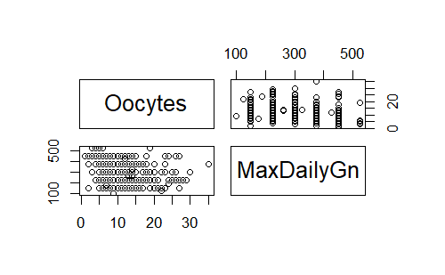

```r
pairs(fertility[, c('Oocytes', 'MaxDailyGn')])
```

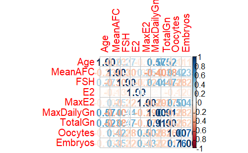

```r
FertCorMat <- cor(fertility, method = 'pearson')
corrplot(FertCorMat, method = 'number')
```

### Linearity: Our model for predicting MeanAFC includes Oocytes and MaxDailyGn. Oocytes has a moderate positive correlation while MaxDailyGn has a moderate negative correlation. Based on correlation and residuals, we can assume linearity

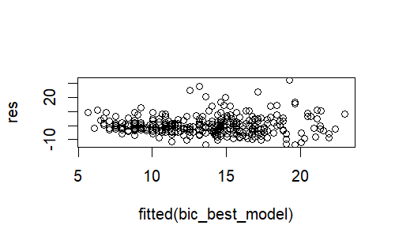

```r
res <- resid(bic_best_model)
plot(fitted(bic_best_model), res)
```

### Independence: It is mentioned that the data collected is from a random sample of women who were having trouble getting pregnant so we can assume independence

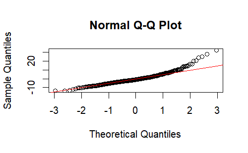

```r
qqnorm(res)
qqline(res, col = 'red')
```

### Normality: Once again, a majority of points follow the reference line but towards the right, points curve upwards, suggesting skewed right residuals

### Equal Variance: The points in the residual plot seem to be randomly scattered around the 0 horizontal line, suggesting constant variance

### (i). What is the coefficient of determination for the model chosen in part f?

### $R^2$ = 0.2596

### (j) To see if the model chosen is the same with step wise selection with BIC, use best subset approach with BIC. Do you still get the same model?

```r
best_subset <- regsubsets(MeanAFC ~ ., data = fertility, nvmax = ncol(fertility) - 1)
summary(best_subset)
```

```
Subset selection object
Call: regsubsets.formula(MeanAFC ~ ., data = fertility, nvmax = ncol(fertility) -
    1)
8 Variables  (and intercept)
           Forced in Forced out
Age            FALSE      FALSE
FSH            FALSE      FALSE
E2             FALSE      FALSE
MaxE2          FALSE      FALSE
MaxDailyGn     FALSE      FALSE
TotalGn        FALSE      FALSE
Oocytes        FALSE      FALSE
Embryos        FALSE      FALSE
1 subsets of each size up to 8
Selection Algorithm: exhaustive
         Age FSH E2  MaxE2 MaxDailyGn
1  ( 1 ) " " " " " " " "   " "
2  ( 1 ) " " " " " " " "   "*"
3  ( 1 ) " " " " "*" " "   "*"
4  ( 1 ) " " "*" "*" " "   "*"
5  ( 1 ) " " "*" "*" " "   "*"
6  ( 1 ) " " "*" "*" " "   "*"
7  ( 1 ) "*" "*" "*" " "   "*"
8  ( 1 ) "*" "*" "*" "*"   "*"
         TotalGn Oocytes Embryos
1  ( 1 ) " "     "*"     " "
2  ( 1 ) " "     "*"     " "
3  ( 1 ) " "     "*"     " "
4  ( 1 ) " "     "*"     " "
5  ( 1 ) " "     "*"     "*"
6  ( 1 ) "*"     "*"     "*"
7  ( 1 ) "*"     "*"     "*"
8  ( 1 ) "*"     "*"     "*"
```

### (k). Check the possible multicollinearity of the above chosen models. Comment on them.

```r
FertFit2 <- lm(MeanAFC ~ MaxDailyGn + Oocytes, data = fertility)
vif(FertFit2)
```

```
MaxDailyGn    Oocytes
   1.08347    1.08347
```

```r
FertFit3 <- lm(MeanAFC ~ E2 + MaxDailyGn + Oocytes, data = fertility)
vif(FertFit3)
```

```
        E2 MaxDailyGn    Oocytes
  1.017432   1.087239   1.101740
```

```r
FertFit4 <- lm(MeanAFC ~ FSH + E2 + MaxDailyGn + Oocytes, data = fertility)
vif(FertFit4)
```

```
       FSH         E2 MaxDailyGn    Oocytes
  1.301786   1.026604   1.284995   1.146892
```

```r
FertFit5 <- lm(MeanAFC ~ FSH + E2 + MaxDailyGn + Oocytes + Embryos, data = fertility)
vif(FertFit5)
```

```
       FSH         E2 MaxDailyGn    Oocytes
  1.301856   1.026605   1.285092   2.486979
   Embryos
  2.351871
```

```r
FertFit6 <- lm(MeanAFC ~ FSH + E2 + MaxDailyGn + TotalGn + Oocytes + Embryos, data = fertility)
vif(FertFit6)
```

```
       FSH         E2 MaxDailyGn    TotalGn
  1.350096   1.029047   5.736215   5.892320
   Oocytes    Embryos
  2.487079   2.351872
```

```r
FertFit7 <- lm(MeanAFC ~ Age + FSH + E2 + MaxDailyGn + TotalGn + Oocytes + Embryos, data = fertility)
vif(FertFit7)
```

```
       Age        FSH         E2 MaxDailyGn
  1.493331   1.352104   1.029048   6.193290
   TotalGn    Oocytes    Embryos
  5.892673   2.509056   2.363348
```

```r
FertFit8 <- lm(MeanAFC ~ Age + FSH + E2 + MaxE2 + MaxDailyGn + TotalGn + Oocytes + Embryos, data = fertility)
vif(FertFit8)
```

```
       Age        FSH         E2      MaxE2
  1.500520   1.353076   1.029520   1.405840
MaxDailyGn    TotalGn    Oocytes    Embryos
  6.238589   5.892978   2.689422   2.385170
```

### The models obtained using AIC and BIC had 4 predictors and 2 predictors respectively. For both models, all VIF values for predictors are close to 1. As for the models with 6, 7, and 8 predictors, there are VIF values greater than 5, suggesting multicollinearity

### (l). Using the models you got from the above different approaches, recommend a final model. When you provide recommendations consider, $R^2$ values, validity of the assumptions, prediction accuracy, multicollinearity.

### I would recommend the model obtained with BIC as a final model. Although it has a smaller coefficient of determination than the model obtained using AIC, it is quite minimal. Additionally, it has more valid assumptions (linearity, independence, and equal variance). Additionally, all VIF values for predictor variables were close to one so multicollinearity is not a problem.